# Blueprints Case Study

Russell Day

7/4/2024

```r
# load necessarily libraries
library(readr)
library(dplyr)
library(ggplot2)
library(tidyr)
library(gridExtra)
```

## Problems

Current problems with the data set include the use of open text responses leading to companies being categorized under different names, items being misrepresented because of different naming conventions ie. Syringe vs Syringes making it hard to run any sort of reliable analysis on it. A majority of the time spent on this project will be on cleaning the data.

## Solutions

The case study will be tackled using a mix of SQL, spreadsheets, and R. SQL and spreadsheets to help clean the data and R for analysis and visualization.

### 1. SQL / spreadsheets (may use some C++ to help)

1. Cleaning mistyped data (null values, wrong types, etc.)
2. Standardize spelling of company names
3. Replacing common item names (ie. 5 ml syringe, 10 ml syringe will both be categorized under syringe)

```r
# csv is this btw: manufacturer, item, quantity of item
inventory_data <- read_csv("inventory_data/blueprints_cleaned_data.csv")
```

```r
head(inventory_data)
```

```
## # A tibble: 6 × 3
##   Manufacturer_Trimmed item_display               Total_Quantity
##   <chr>                <chr>                               <dbl>
## 1 zoll                 start up kit                            1
## 2 writesite plus       prep resistant skin marker              1
## 3 wright and fillipis  large bag with a zipper                 2
## 4 womancare global     flexible karman cannula                 9
## 5 wipak medical        sealable bag                          100
## 6 wipak medical        sterilization pouches                 101
```

```r
summary(inventory_data)
```

```
##  Manufacturer_Trimmed item_display       Total_Quantity
##  Length:1000          Length:1000        Min.   :   1.0
##  Class :character     Class :character   1st Qu.:   1.0
##  Mode  :character     Mode  :character   Median :   3.0
##                                          Mean   :  60.7
##                                          3rd Qu.:  15.0
##                                          Max.   :7000.0
```

### 2. R

1. Data analysis
   1. Averages
   2. Summary statistics
2. Data visualization
   1. Pie charts with % items (by company)
   2. Pie charts with % items (from X company pool)

[figure not shown]

[figure not shown]

[output not shown]

[figure not shown]

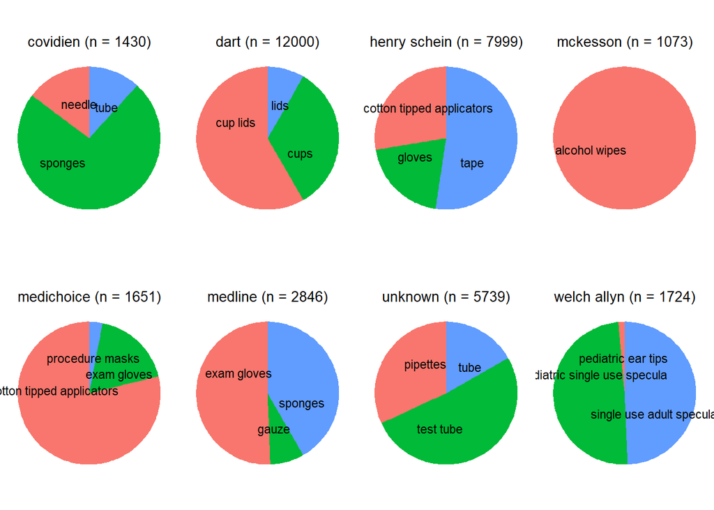

```r
# making pie charts for the top 8 manufacturers
top_8_manufacturers <- inventory_data %>%
  group_by(Manufacturer_Trimmed) %>%
  summarize(Total_Quantity = sum(Total_Quantity)) %>%
  top_n(8, Total_Quantity) %>%
  pull(Manufacturer_Trimmed)

top_8_data <- inventory_data %>%
  filter(Manufacturer_Trimmed %in% top_8_manufacturers) %>%
  group_by(Manufacturer_Trimmed) %>%
  mutate(Rank = rank(-Total_Quantity, ties.method = "first")) %>%
  filter(Rank <= 3) %>%
  ungroup()

# Function to create a pie chart for a single manufacturer
create_pie_chart <- function(data, manufacturer) {
  total_items <- sum(data$Total_Quantity)

  ggplot(data, aes(x = "", y = Total_Quantity, fill = item_display)) +
    geom_bar(stat = "identity", width = 1) +
    coord_polar("y", start = 0) +
    theme_void() +
    theme(
      legend.position = "none",
      plot.title = element_text(size = 10, hjust = 0.5)
    ) +
    ggtitle(paste0(manufacturer, " (n = ", total_items, ")")) +
    geom_text(aes(label = item_display), position = position_stack(vjust = 0.7), size = 3)
}

# Create pie charts for each manufacturer
pie_charts <- lapply(top_8_manufacturers, function(manufacturer) {
  manufacturer_data <- top_8_data %>%
    filter(Manufacturer_Trimmed == manufacturer) %>%
    arrange(desc(Total_Quantity)) %>%
    top_n(5, Total_Quantity)  # Limiting to top 5 for better readability
  create_pie_chart(manufacturer_data, manufacturer)
})

# Arrange pie charts in a grid
pie_chart_grid <- do.call(grid.arrange, c(pie_charts, ncol = 4))
```

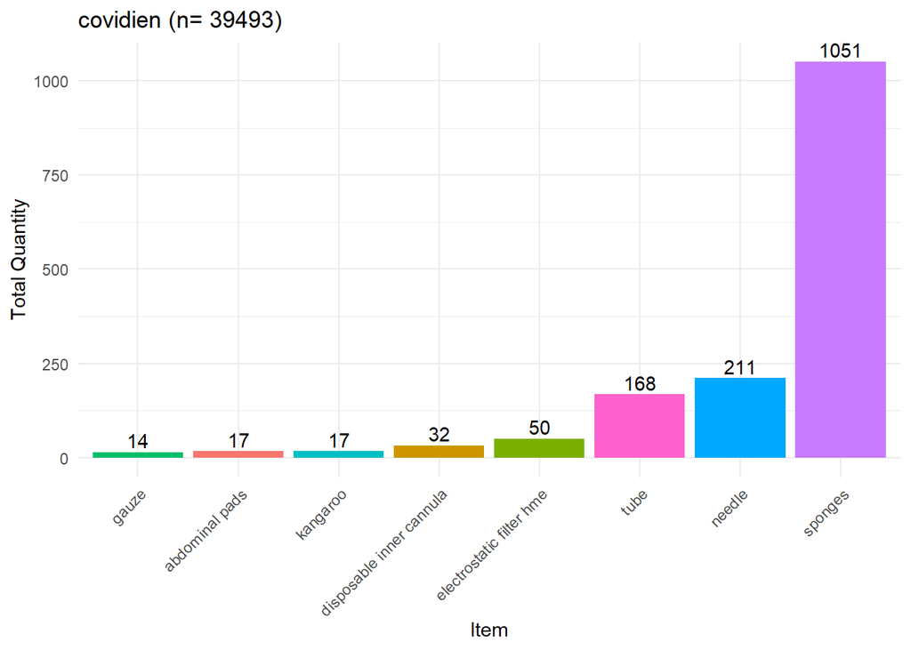

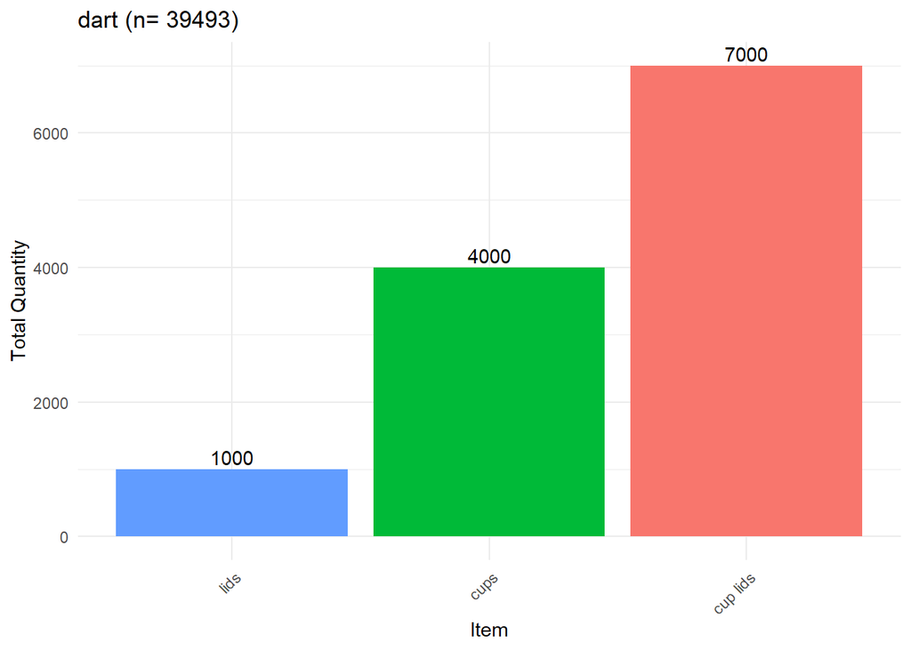

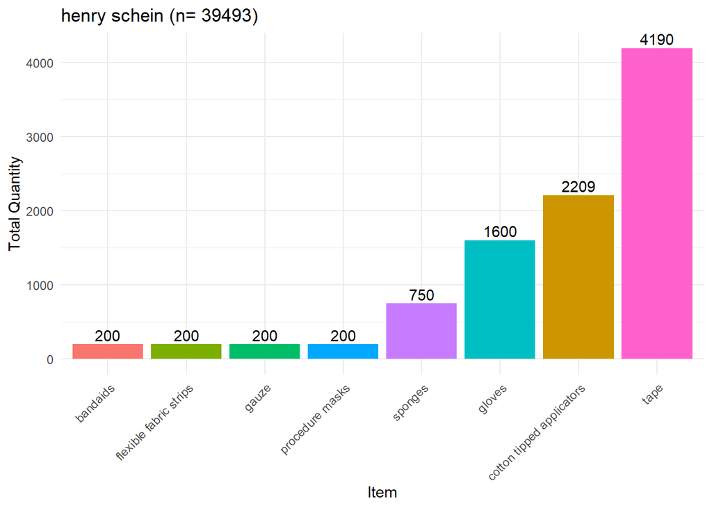

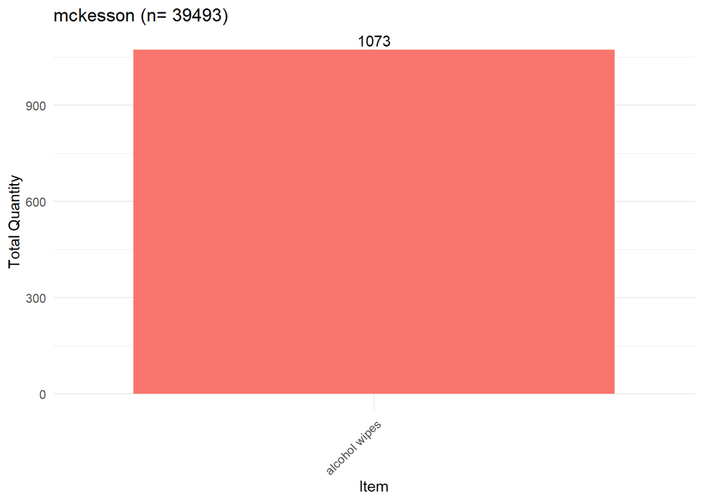

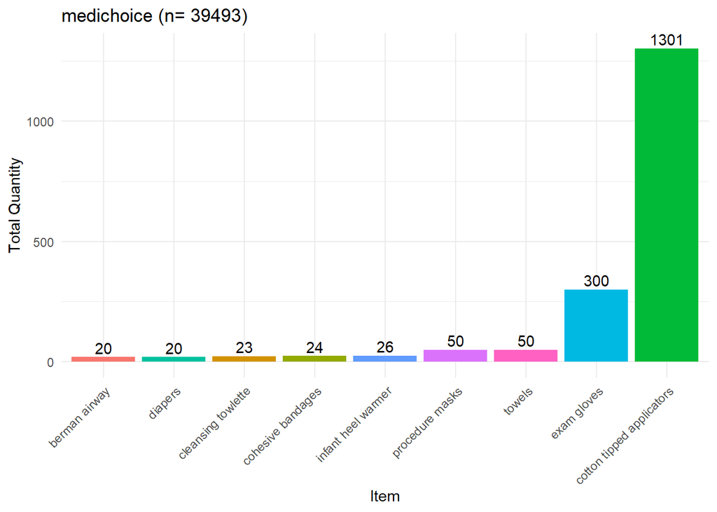

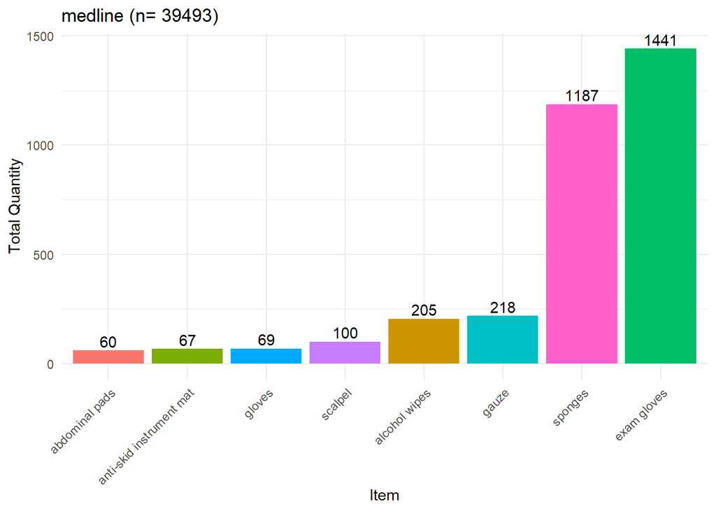

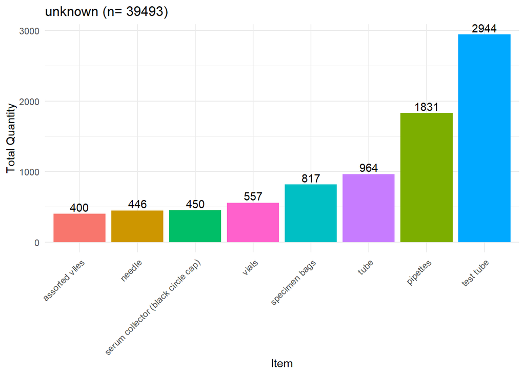

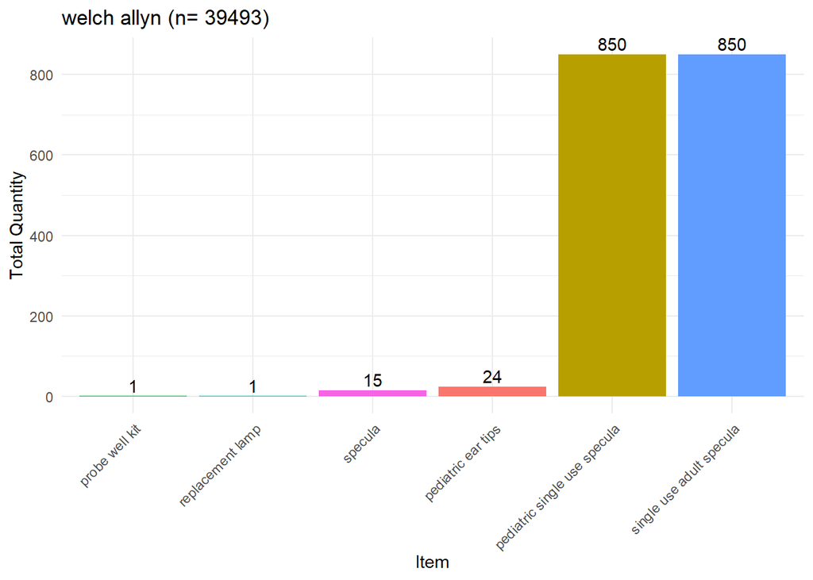

```r
# Calculate total quantities and determine top manufacturers and items
top_data <- inventory_data %>%
  group_by(Manufacturer_Trimmed, item_display) %>%
  summarise(Total_Quantity = sum(Total_Quantity), .groups = 'drop') %>%
  arrange(desc(Total_Quantity))

# Get top 8 manufacturers by overall quantity
top_manufacturers <- top_data %>%
  group_by(Manufacturer_Trimmed) %>%
  summarise(Total_Manufacturer_Quantity = sum(Total_Quantity)) %>%
  top_n(8, Total_Manufacturer_Quantity) %>%
  pull(Manufacturer_Trimmed)

# Filter data for only top 8 manufacturers and get top 5 items for each
final_data <- top_data %>%
  filter(Manufacturer_Trimmed %in% top_manufacturers) %>%
  group_by(Manufacturer_Trimmed) %>%
  slice_max(order_by = Total_Quantity, n = 8)

# Generate plots for each manufacturer
plot_list <- lapply(unique(final_data$Manufacturer_Trimmed), function(manufacturer) {
  total_items <- sum(final_data$Total_Quantity)
  data <- final_data %>% filter(Manufacturer_Trimmed == manufacturer)
  ggplot(data, aes(x = reorder(item_display, Total_Quantity), y = Total_Quantity, fill = item_display)) +
    geom_col() +
    labs(title = paste0(manufacturer, " (n= " ,total_items, ")"), x = "Item", y = "Total Quantity") +
    theme_minimal() +
    theme(axis.text.x = element_text(angle = 45, hjust = 1), legend.position = "none") +
    geom_text(aes(label = Total_Quantity, vjust = -0.3))
})

for (plot in plot_list) {
  print(plot)
}
```

## Conclusion

The findings underscore the challenges posed by open text responses and varied naming conventions, which have led to discrepancies in company categorization and item representation. These issues not only complicate the inventory process but also impede the organization’s ability to swiftly and accurately assess resource distribution needs.

## Next Steps

Next steps for our inventory process would be creating a more standardized way of categorizing our items. From the app design team, this data will help to quicken the process of sorting by creating a drop down menu that will change based off of the data collected here.

## Thanks for reading!

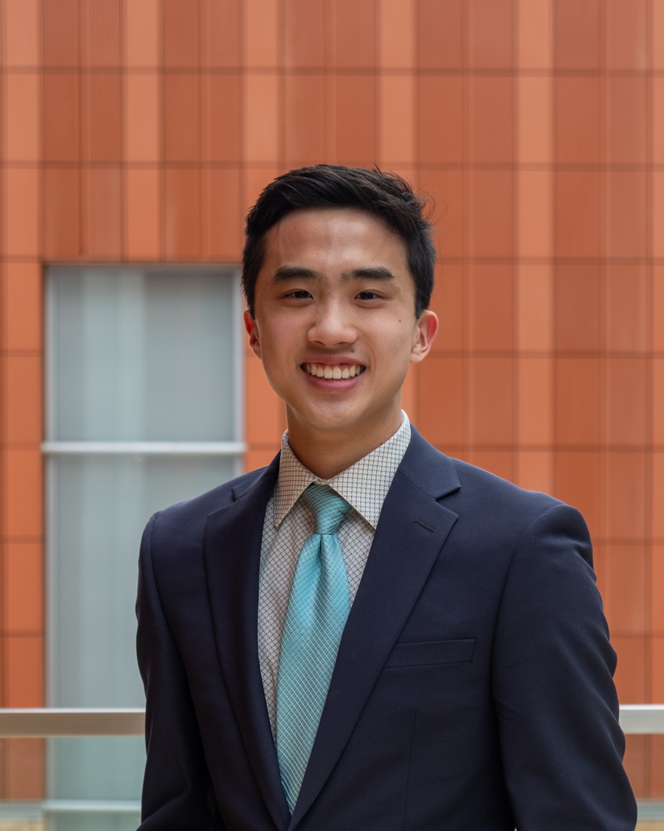

Hello! Thank you for going over my case study. Hope it helps and let me know if you want any specific details or if you have any issues with it.

[LinkedIn](https://www.linkedin.com/in/russell-day) [LinkedIn](https://www.linkedin.com/in/russell-day)